# SPSS Decision Tree Output

[output not shown]

Log  
Log - Log - July 26, 2017

* Decision Tree.  
TREE DefaultedLoans [n] BY InterestType [n] MortgageType [n] NewLoan [n] ProbationaryLoans [n]  
LTVCategory [n] MortgageYears [s] CreditRatingMovement [s] LTV [s] LoanBalance [s] InterestIncome  
[s] PropertyValue [s] AnnualPYMT [s] AddressLatitude [s] AddressLongitude [s] InArrears [n]  
ArrearsCategory [n] CreditRating [n] County [n]  
/TREE DISPLAY=TOPDOWN NODES=STATISTICS BRANCHSTATISTICS=YES NODEDEFS=YES SCALE=AUTO  
/DEPCATEGORIES USEVALUES=[VALID]  
/PRINT MODELSUMMARY CLASSIFICATION RISK  
/RULES NODES=ALL SYNTAX=GENERIC LABELS=YES  
/METHOD TYPE=CHAID  
/GROWTHLIMIT MAXDEPTH=AUTO MINPARENTSIZE=100 MINCHILDSIZE=50  
/VALIDATION TYPE=SPLITSAMPLE(60.00) OUTPUT=BOTHSAMPLES  
/CHAID ALPHASPLIT=0.05 ALPHAMERGE=0.05 SPLITMERGED=NO CHISQUARE=PEARSON CONVERGE=0.001  
MAXITERATIONS=100 ADJUST=BONFERRONI INTERVALS=10  
/COSTS EQUAL  
/MISSING NOMINALMISSING=MISSING.

**Classification Tree ( Limited Variables)**  
Classification Tree - Notes - July 26, 2017

NotesNotes, table, 0 levels of column headers and 2 levels of row headers, table with 3 columns and 15 rows

| Output Created |  | 26-JUL-2017 22:27:03 |
| --- | --- | --- |
| Comments |  |  |
| Input | Data | E:\KPMG\Data\KPMG DT.sav |
|  | Active Dataset | DataSet1 |
|  | Filter | <none> |
|  | Weight | <none> |
|  | Split File | <none> |
|  | N of Rows in Working Data File | 237389 |
| Missing Value Handling | Definition of Missing | Handling of user-defined missing values of nominal independent variables depends on the growing method. |
|  | Cases Used | Only cases with valid data for the dependent variable and some or all independent variables are used in computing any statistics. |
| Syntax |  | TREE DefaultedLoans [n] BY InterestType [n] MortgageType [n] NewLoan [n] ProbationaryLoans [n] LTVCategory [n] MortgageYears [s] CreditRatingMovement [s] LTV [s] LoanBalance [s] InterestIncome [s] Pro… |
| Resources | Processor Time | 00:00:20.91 |
|  | Elapsed Time | 00:00:23.27 |
| Files Saved | Rules File |  |

**Classification Tree ( Limited Variables)**  
Classification Tree - Warnings - July 26, 2017

WarningsWarnings, table, 0 levels of column headers and 0 levels of row headers, table with 1 columns and 3 rows

| Gain summary Tables are not displayed because profits are undefined. |
| --- |
| Target category gains tables are not displayed because target categories are undefined. |

**Classification Tree ( Limited Variables)**  
Classification Tree - Model Summary - July 26, 2017

Model SummaryModel Summary, table, 0 levels of column headers and 2 levels of row headers, table with 3 columns and 12 rows

| Specifications | Growing Method | CHAID |
| --- | --- | --- |
|  | Dependent Variable | DefaultedLoans |
|  | Independent Variables | InterestType, MortgageType, NewLoan, ProbationaryLoans, LTVCategory, MortgageYears, CreditRatingMovement, LTV, LoanBalance, InterestIncome, PropertyValue, AnnualPYMT, AddressLatitude, AddressLongitude… |
|  | Validation | Split Sample |
|  | Maximum Tree Depth | 3 |
|  | Minimum Cases in Parent Node | 100 |
|  | Minimum Cases in Child Node | 50 |
| Results | Independent Variables Included | CreditRating, ProbationaryLoans, LTVCategory, PropertyValue, CreditRatingMovement |
|  | Number of Nodes | 16 |
|  | Number of Terminal Nodes | 10 |
|  | Depth | 3 |

Training Sample  
Training Sample - Tree Diagram - July 26, 2017

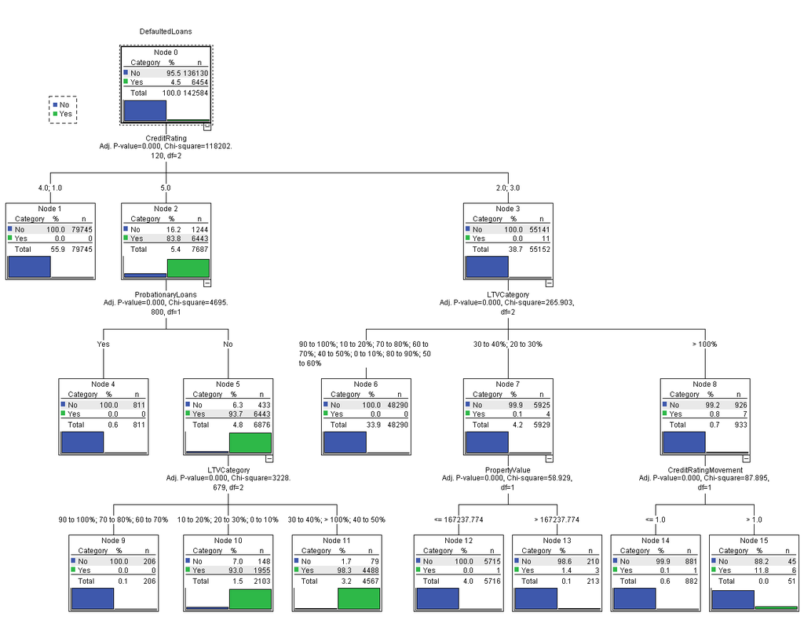

Test Sample  
Test Sample - Tree Diagram - July 26, 2017

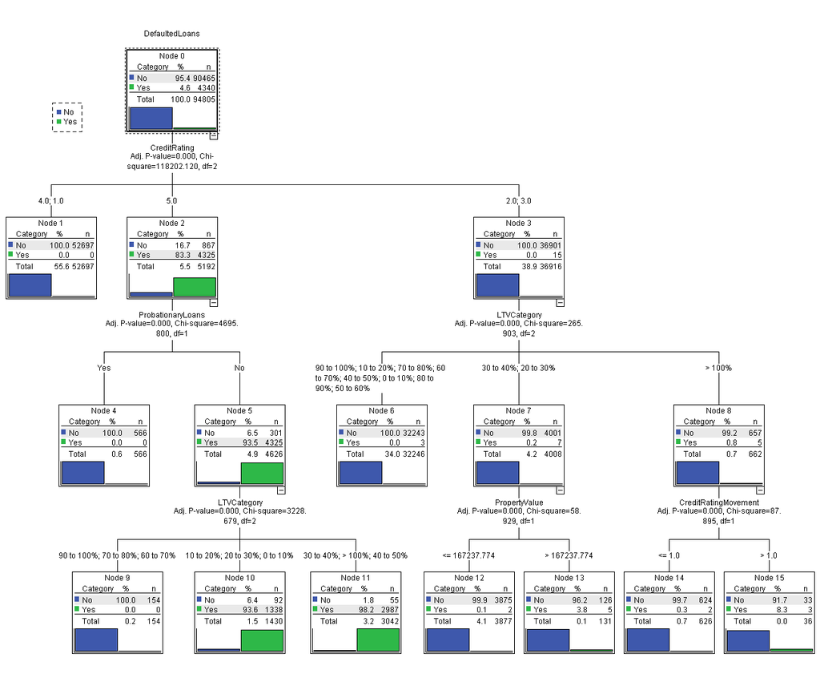

**Classification Tree ( Limited Variables)**  
Classification Tree - Risk - July 26, 2017

RiskRisk, table, 1 levels of column headers and 1 levels of row headers, table with 3 columns and 5 rows

| Sample | Estimate | Std. Error |
| --- | --- | --- |
| Training | .002 | .000 |
| Test | .002 | .000 |

Growing Method: CHAID Dependent Variable: DefaultedLoans

**Classification Tree ( Limited Variables)**  
Classification Tree - Classification - July 26, 2017

ClassificationClassification, table, 2 levels of column headers and 2 levels of row headers, table with 5 columns and 10 rows

| Sample | Observed | Predicted |  |  |
| --- | --- | --- | --- | --- |
|  |  | No | Yes | Percent Correct |
| Training | No | 135903 | 227 | 99.8% |
|  | Yes | 11 | 6443 | 99.8% |
|  | Overall Percentage | 95.3% | 4.7% | 99.8% |
| Test | No | 90318 | 147 | 99.8% |
|  | Yes | 15 | 4325 | 99.7% |
|  | Overall Percentage | 95.3% | 4.7% | 99.8% |

Growing Method: CHAID Dependent Variable: DefaultedLoans

**Classification Tree ( Limited Variables)**  
Classification Tree - Rules - July 26, 2017

/* Node 0 */.  
IF (1)  
THEN  
Node = 0  
Prediction = 'No'  
Probability = 0.954735  
/* Node 1 */.  
IF (CreditRating != 5 AND CreditRating != 2 AND CreditRating != 3)  
THEN  
Node = 1  
Prediction = 'No'  
Probability = 1.000000  
/* Node 2 */.  
IF (CreditRating = 5)  
THEN  
Node = 2  
Prediction = 'Yes'  
Probability = 0.838168  
/* Node 4 */.  
IF (CreditRating = 5) AND (ProbationaryLoans = "Yes")  
THEN  
Node = 4  
Prediction = 'No'  
Probability = 1.000000  
/* Node 5 */.  
IF (CreditRating = 5) AND (ProbationaryLoans != "Yes")  
THEN  
Node = 5  
Prediction = 'Yes'  
Probability = 0.937027  
/* Node 9 */.  
IF (CreditRating = 5) AND (ProbationaryLoans != "Yes") AND (LTVCategory = "90 to 100%" OR LTVCategory = "70 to 80%" OR LTVCategory = "60 to 70%")  
THEN  
Node = 9  
Prediction = 'No'  
Probability = 1.000000  
/* Node 10 */.  
IF (CreditRating = 5) AND (ProbationaryLoans != "Yes") AND (LTVCategory = "10 to 20%" OR LTVCategory = "20 to 30%" OR LTVCategory = "0 to 10%")  
THEN  
Node = 10  
Prediction = 'Yes'  
Probability = 0.929624  
/* Node 11 */.  
IF (CreditRating = 5) AND (ProbationaryLoans != "Yes") AND (LTVCategory != "90 to 100%" AND LTVCategory != "10 to 20%" AND LTVCategory != "70 to 80%" AND LTVCategory != "60 to 70%" AND LTVCategory != "20 to 30%" AND LTVCategory != "0 to 10%")  
THEN  
Node = 11  
Prediction = 'Yes'  
Probability = 0.982702  
/* Node 3 */.  
IF (CreditRating = 2 OR CreditRating = 3)  
THEN  
Node = 3  
Prediction = 'No'  
Probability = 0.999801  
/* Node 6 */.  
IF (CreditRating = 2 OR CreditRating = 3) AND (LTVCategory != "30 to 40%" AND LTVCategory != "20 to 30%" AND LTVCategory != "> 100%")  
THEN  
Node = 6  
Prediction = 'No'  
Probability = 1.000000  
/* Node 7 */.  
IF (CreditRating = 2 OR CreditRating = 3) AND (LTVCategory = "30 to 40%" OR LTVCategory = "20 to 30%")  
THEN  
Node = 7  
Prediction = 'No'  
Probability = 0.999325  
/* Node 12 */.  
IF (CreditRating = 2 OR CreditRating = 3) AND (LTVCategory = "30 to 40%" OR LTVCategory = "20 to 30%") AND (PropertyValue IS MISSING OR (PropertyValue <= 167237.7737089636))  
THEN  
Node = 12  
Prediction = 'No'  
Probability = 0.999825  
/* Node 13 */.  
IF (CreditRating = 2 OR CreditRating = 3) AND (LTVCategory = "30 to 40%" OR LTVCategory = "20 to 30%") AND (PropertyValue NOT MISSING AND (PropertyValue > 167237.7737089636))  
THEN  
Node = 13  
Prediction = 'No'  
Probability = 0.985915  
/* Node 8 */.  
IF (CreditRating = 2 OR CreditRating = 3) AND (LTVCategory = "> 100%")  
THEN  
Node = 8  
Prediction = 'No'  
Probability = 0.992497  
/* Node 14 */.  
IF (CreditRating = 2 OR CreditRating = 3) AND (LTVCategory = "> 100%") AND (CreditRatingMovement IS MISSING OR (CreditRatingMovement <= 1))  
THEN  
Node = 14  
Prediction = 'No'  
Probability = 0.998866  
/* Node 15 */.  
IF (CreditRating = 2 OR CreditRating = 3) AND (LTVCategory = "> 100%") AND (CreditRatingMovement NOT MISSING AND (CreditRatingMovement > 1))  
THEN  
Node = 15  
Prediction = 'No'  
Probability = 0.882353

Log  
Log - Log - July 26, 2017

* Decision Tree.  
TREE DefaultedLoans [n] BY InterestType [n] MortgageType [n] NewLoan [n] ProbationaryLoans [n]  
LTVCategory [n] MortgageYears [s] CreditRatingMovement [s] LTV [s] LoanBalance [s] InterestIncome  
[s] PropertyValue [s] AnnualPYMT [s] AddressLatitude [s] AddressLongitude [s] InArrears [n]  
ArrearsCategory [n] County [n]  
/TREE DISPLAY=TOPDOWN NODES=STATISTICS BRANCHSTATISTICS=YES NODEDEFS=YES SCALE=AUTO  
/DEPCATEGORIES USEVALUES=[VALID]  
/PRINT MODELSUMMARY CLASSIFICATION RISK  
/RULES NODES=ALL SYNTAX=GENERIC LABELS=YES  
/METHOD TYPE=CHAID  
/GROWTHLIMIT MAXDEPTH=AUTO MINPARENTSIZE=100 MINCHILDSIZE=50  
/VALIDATION TYPE=SPLITSAMPLE(60.00) OUTPUT=BOTHSAMPLES  
/CHAID ALPHASPLIT=0.05 ALPHAMERGE=0.05 SPLITMERGED=NO CHISQUARE=PEARSON CONVERGE=0.001  
MAXITERATIONS=100 ADJUST=BONFERRONI INTERVALS=10  
/COSTS EQUAL  
/INFLUENCE CreditRating  
/MISSING NOMINALMISSING=MISSING.

Classification Tree  
Classification Tree - Notes - July 26, 2017

NotesNotes, table, 0 levels of column headers and 2 levels of row headers, table with 3 columns and 16 rows

| Output Created |  | 26-JUL-2017 22:29:16 |
| --- | --- | --- |
| Comments |  |  |
| Input | Data | E:\KPMG\Data\KPMG DT.sav |
|  | Active Dataset | DataSet1 |
|  | Filter | <none> |
|  | Weight | <none> |
|  | Split File | <none> |
|  | N of Rows in Working Data File | 237389 |
|  | Influence Variable | CreditRating |
| Missing Value Handling | Definition of Missing | Handling of user-defined missing values of nominal independent variables depends on the growing method. |
|  | Cases Used | Only cases with valid data for the dependent variable and some or all independent variables are used in computing any statistics. |
| Syntax |  | TREE DefaultedLoans [n] BY InterestType [n] MortgageType [n] NewLoan [n] ProbationaryLoans [n] LTVCategory [n] MortgageYears [s] CreditRatingMovement [s] LTV [s] LoanBalance [s] InterestIncome [s] Pro… |
| Resources | Processor Time | 00:00:22.22 |
|  | Elapsed Time | 00:00:22.65 |
| Files Saved | Rules File |  |

Classification Tree  
Classification Tree - Warnings - July 26, 2017

WarningsWarnings, table, 0 levels of column headers and 0 levels of row headers, table with 1 columns and 3 rows

| Gain summary Tables are not displayed because profits are undefined. |
| --- |
| Target category gains tables are not displayed because target categories are undefined. |

Classification Tree  
Classification Tree - Model Summary - July 26, 2017

Model SummaryModel Summary, table, 0 levels of column headers and 2 levels of row headers, table with 3 columns and 12 rows

| Specifications | Growing Method | CHAID |
| --- | --- | --- |
|  | Dependent Variable | DefaultedLoans |
|  | Independent Variables | InterestType, MortgageType, NewLoan, ProbationaryLoans, LTVCategory, MortgageYears, CreditRatingMovement, LTV, LoanBalance, InterestIncome, PropertyValue, AnnualPYMT, AddressLatitude, AddressLongitude… |
|  | Validation | Split Sample |
|  | Maximum Tree Depth | 3 |
|  | Minimum Cases in Parent Node | 100 |
|  | Minimum Cases in Child Node | 50 |
| Results | Independent Variables Included | LTVCategory, CreditRatingMovement, County, LoanBalance, ProbationaryLoans, PropertyValue, AnnualPYMT, MortgageYears |
|  | Number of Nodes | 73 |
|  | Number of Terminal Nodes | 49 |
|  | Depth | 3 |

Training Sample  
Training Sample - Tree Diagram - July 26, 2017

[figure not shown]

Test Sample  
Test Sample - Tree Diagram - July 26, 2017

[figure not shown]

Classification Tree  
Classification Tree - Risk - July 26, 2017

RiskRisk, table, 1 levels of column headers and 1 levels of row headers, table with 3 columns and 5 rows

| Sample | Estimate | Std. Error |
| --- | --- | --- |
| Training | .014 | .000 |
| Test | .014 | .000 |

Growing Method: CHAID Dependent Variable: DefaultedLoans

Classification Tree  
Classification Tree - Classification - July 26, 2017

ClassificationClassification, table, 2 levels of column headers and 2 levels of row headers, table with 5 columns and 10 rows

| Sample | Observed | Predicted |  |  |
| --- | --- | --- | --- | --- |
|  |  | No | Yes | Percent Correct |
| Training | No | 134283 | 1577 | 98.8% |
|  | Yes | 349 | 6146 | 94.6% |
|  | Overall Percentage | 94.6% | 5.4% | 98.6% |
| Test | No | 89665 | 1070 | 98.8% |
|  | Yes | 251 | 4048 | 94.2% |
|  | Overall Percentage | 94.6% | 5.4% | 98.6% |

Growing Method: CHAID Dependent Variable: DefaultedLoans

Classification Tree  
Classification Tree - Rules - July 26, 2017

/* Node 0 */.  
IF (1)  
THEN  
Node = 0  
Prediction = 'No'  
Probability = 0.954375  
/* Node 1 */.  
IF (LTVCategory != "10 to 20%" AND LTVCategory != "30 to 40%" AND LTVCategory != "> 100%" AND LTVCategory != "20 to 30%" AND LTVCategory != "0 to 10%" AND LTVCategory != "40 to 50%")  
THEN  
Node = 1  
Prediction = 'No'  
Probability = 1.000000  
/* Node 2 */.  
IF (LTVCategory = "10 to 20%" OR LTVCategory = "30 to 40%")  
THEN  
Node = 2  
Prediction = 'No'  
Probability = 0.937253  
/* Node 7 */.  
IF (LTVCategory = "10 to 20%" OR LTVCategory = "30 to 40%") AND (CreditRatingMovement IS MISSING OR (CreditRatingMovement <= 0))  
THEN  
Node = 7  
Prediction = 'No'  
Probability = 0.999940  
/* Node 29 */.  
IF (LTVCategory = "10 to 20%" OR LTVCategory = "30 to 40%") AND (CreditRatingMovement IS MISSING OR (CreditRatingMovement <= 0)) AND (County != "Mayo")  
THEN  
Node = 29  
Prediction = 'No'  
Probability = 1.000000  
/* Node 30 */.  
IF (LTVCategory = "10 to 20%" OR LTVCategory = "30 to 40%") AND (CreditRatingMovement IS MISSING OR (CreditRatingMovement <= 0)) AND (County = "Mayo")  
THEN  
Node = 30  
Prediction = 'No'  
Probability = 0.997537  
/* Node 8 */.  
IF (LTVCategory = "10 to 20%" OR LTVCategory = "30 to 40%") AND (CreditRatingMovement NOT MISSING AND (CreditRatingMovement > 0 AND CreditRatingMovement <= 1))  
THEN  
Node = 8  
Prediction = 'No'  
Probability = 0.750394  
/* Node 31 */.  
IF (LTVCategory = "10 to 20%" OR LTVCategory = "30 to 40%") AND (CreditRatingMovement NOT MISSING AND (CreditRatingMovement > 0 AND CreditRatingMovement <= 1)) AND (LoanBalance IS MISSING OR (LoanBalance <= 21304.09948140605))  
THEN  
Node = 31  
Prediction = 'No'  
Probability = 0.798246  
/* Node 32 */.  
IF (LTVCategory = "10 to 20%" OR LTVCategory = "30 to 40%") AND (CreditRatingMovement NOT MISSING AND (CreditRatingMovement > 0 AND CreditRatingMovement <= 1)) AND (LoanBalance NOT MISSING AND (LoanBalance > 21304.09948140605 AND LoanBalance <= 41525.36648326072))  
THEN  
Node = 32  
Prediction = 'No'  
Probability = 0.933333  
/* Node 33 */.  
IF (LTVCategory = "10 to 20%" OR LTVCategory = "30 to 40%") AND (CreditRatingMovement NOT MISSING AND (CreditRatingMovement > 0 AND CreditRatingMovement <= 1)) AND (LoanBalance NOT MISSING AND (LoanBalance > 41525.36648326072 AND LoanBalance <= 62199.91219748573))  
THEN  
Node = 33  
Prediction = 'No'  
Probability = 0.815972  
/* Node 34 */.  
IF (LTVCategory = "10 to 20%" OR LTVCategory = "30 to 40%") AND (CreditRatingMovement NOT MISSING AND (CreditRatingMovement > 0 AND CreditRatingMovement <= 1)) AND (LoanBalance NOT MISSING AND (LoanBalance > 62199.91219748573 AND LoanBalance <= 82194.53984315523))  
THEN  
Node = 34  
Prediction = 'Yes'  
Probability = 0.959596  
/* Node 35 */.  
IF (LTVCategory = "10 to 20%" OR LTVCategory = "30 to 40%") AND (CreditRatingMovement NOT MISSING AND (CreditRatingMovement > 0 AND CreditRatingMovement <= 1)) AND (LoanBalance NOT MISSING AND (LoanBalance > 82194.53984315523))  
THEN  
Node = 35  
Prediction = 'Yes'  
Probability = 1.000000  
/* Node 9 */.  
IF (LTVCategory = "10 to 20%" OR LTVCategory = "30 to 40%") AND (CreditRatingMovement NOT MISSING AND (CreditRatingMovement > 1))  
THEN  
Node = 9  
Prediction = 'Yes'  
Probability = 0.450962  
/* Node 36 */.  
IF (LTVCategory = "10 to 20%" OR LTVCategory = "30 to 40%") AND (CreditRatingMovement NOT MISSING AND (CreditRatingMovement > 1)) AND (ProbationaryLoans != "Yes")  
THEN  
Node = 36  
Prediction = 'Yes'  
Probability = 0.592546  
/* Node 37 */.  
IF (LTVCategory = "10 to 20%" OR LTVCategory = "30 to 40%") AND (CreditRatingMovement NOT MISSING AND (CreditRatingMovement > 1)) AND (ProbationaryLoans = "Yes")  
THEN  
Node = 37  
Prediction = 'No'  
Probability = 1.000000  
/* Node 3 */.  
IF (LTVCategory = "> 100%")  
THEN  
Node = 3  
Prediction = 'Yes'  
Probability = 0.626000  
/* Node 10 */.  
IF (LTVCategory = "> 100%") AND (PropertyValue NOT MISSING AND (PropertyValue <= 79341.02271322564))  
THEN  
Node = 10  
Prediction = 'Yes'  
Probability = 0.680219  
/* Node 38 */.  
IF (LTVCategory = "> 100%") AND (PropertyValue NOT MISSING AND (PropertyValue <= 79341.02271322564)) AND (ProbationaryLoans != "Yes")  
THEN  
Node = 38  
Prediction = 'Yes'  
Probability = 0.752595  
/* Node 39 */.  
IF (LTVCategory = "> 100%") AND (PropertyValue NOT MISSING AND (PropertyValue <= 79341.02271322564)) AND (ProbationaryLoans = "Yes")  
THEN  
Node = 39  
Prediction = 'No'  
Probability = 1.000000  
/* Node 11 */.  
IF (LTVCategory = "> 100%") AND (PropertyValue NOT MISSING AND (PropertyValue > 79341.02271322564 AND PropertyValue <= 94870.85044056918))  
THEN  
Node = 11  
Prediction = 'Yes'  
Probability = 0.588777  
/* Node 40 */.  
IF (LTVCategory = "> 100%") AND (PropertyValue NOT MISSING AND (PropertyValue > 79341.02271322564 AND PropertyValue <= 94870.85044056918)) AND (LoanBalance NOT MISSING AND (LoanBalance <= 102869.0855573803))  
THEN  
Node = 40  
Prediction = 'No'  
Probability = 0.835034  
/* Node 41 */.  
IF (LTVCategory = "> 100%") AND (PropertyValue NOT MISSING AND (PropertyValue > 79341.02271322564 AND PropertyValue <= 94870.85044056918)) AND (LoanBalance IS MISSING OR (LoanBalance > 102869.0855573803))  
THEN  
Node = 41  
Prediction = 'Yes'  
Probability = 1.000000  
/* Node 12 */.  
IF (LTVCategory = "> 100%") AND (PropertyValue NOT MISSING AND (PropertyValue > 94870.85044056918 AND PropertyValue <= 110080.7885801365))  
THEN  
Node = 12  
Prediction = 'Yes'  
Probability = 0.915942  
/* Node 42 */.  
IF (LTVCategory = "> 100%") AND (PropertyValue NOT MISSING AND (PropertyValue > 94870.85044056918 AND PropertyValue <= 110080.7885801365)) AND (LoanBalance NOT MISSING AND (LoanBalance <= 102869.0855573803))  
THEN  
Node = 42  
Prediction = 'No'  
Probability = 0.888889  
/* Node 43 */.  
IF (LTVCategory = "> 100%") AND (PropertyValue NOT MISSING AND (PropertyValue > 94870.85044056918 AND PropertyValue <= 110080.7885801365)) AND (LoanBalance NOT MISSING AND (LoanBalance > 102869.0855573803 AND LoanBalance <= 123090.3525592349))  
THEN  
Node = 43  
Prediction = 'Yes'  
Probability = 0.981818  
/* Node 44 */.  
IF (LTVCategory = "> 100%") AND (PropertyValue NOT MISSING AND (PropertyValue > 94870.85044056918 AND PropertyValue <= 110080.7885801365)) AND (LoanBalance IS MISSING OR (LoanBalance > 123090.3525592349))  
THEN  
Node = 44  
Prediction = 'Yes'  
Probability = 1.000000  
/* Node 13 */.  
IF (LTVCategory = "> 100%") AND (PropertyValue IS MISSING OR (PropertyValue > 110080.7885801365 AND PropertyValue <= 167306.0696344106))  
THEN  
Node = 13  
Prediction = 'Yes'  
Probability = 0.991342  
/* Node 45 */.  
IF (LTVCategory = "> 100%") AND (PropertyValue IS MISSING OR (PropertyValue > 110080.7885801365 AND PropertyValue <= 167306.0696344106)) AND (LoanBalance NOT MISSING AND (LoanBalance <= 163935.8009739401))  
THEN  
Node = 45  
Prediction = 'Yes'  
Probability = 0.973970  
/* Node 46 */.  
IF (LTVCategory = "> 100%") AND (PropertyValue IS MISSING OR (PropertyValue > 110080.7885801365 AND PropertyValue <= 167306.0696344106)) AND (LoanBalance NOT MISSING AND (LoanBalance > 163935.8009739401 AND LoanBalance <= 184635.5288388524))  
THEN  
Node = 46  
Prediction = 'Yes'  
Probability = 1.000000  
/* Node 47 */.  
IF (LTVCategory = "> 100%") AND (PropertyValue IS MISSING OR (PropertyValue > 110080.7885801365 AND PropertyValue <= 167306.0696344106)) AND (LoanBalance IS MISSING OR (LoanBalance > 184635.5288388524))  
THEN  
Node = 47  
Prediction = 'Yes'  
Probability = 1.000000  
/* Node 14 */.  
IF (LTVCategory = "> 100%") AND (PropertyValue NOT MISSING AND (PropertyValue > 167306.0696344106 AND PropertyValue <= 191625.8179008559))  
THEN  
Node = 14  
Prediction = 'Yes'  
Probability = 0.385214  
/* Node 48 */.  
IF (LTVCategory = "> 100%") AND (PropertyValue NOT MISSING AND (PropertyValue > 167306.0696344106 AND PropertyValue <= 191625.8179008559)) AND (CreditRatingMovement NOT MISSING AND (CreditRatingMovement <= 0))  
THEN  
Node = 48  
Prediction = 'No'  
Probability = 1.000000  
/* Node 49 */.  
IF (LTVCategory = "> 100%") AND (PropertyValue NOT MISSING AND (PropertyValue > 167306.0696344106 AND PropertyValue <= 191625.8179008559)) AND (CreditRatingMovement IS MISSING OR (CreditRatingMovement > 0))  
THEN  
Node = 49  
Prediction = 'Yes'  
Probability = 0.761538  
/* Node 15 */.  
IF (LTVCategory = "> 100%") AND (PropertyValue NOT MISSING AND (PropertyValue > 191625.8179008559 AND PropertyValue <= 250599.4319125898))  
THEN  
Node = 15  
Prediction = 'No'  
Probability = 1.000000  
/* Node 16 */.  
IF (LTVCategory = "> 100%") AND (PropertyValue NOT MISSING AND (PropertyValue > 250599.4319125898))  
THEN  
Node = 16  
Prediction = 'No'  
Probability = 0.983607  
/* Node 4 */.  
IF (LTVCategory = "20 to 30%")  
THEN  
Node = 4  
Prediction = 'No'  
Probability = 0.802990  
/* Node 17 */.  
IF (LTVCategory = "20 to 30%") AND (CreditRatingMovement IS MISSING OR (CreditRatingMovement <= 0))  
THEN  
Node = 17  
Prediction = 'No'  
Probability = 0.999277  
/* Node 50 */.  
IF (LTVCategory = "20 to 30%") AND (CreditRatingMovement IS MISSING OR (CreditRatingMovement <= 0)) AND (LoanBalance NOT MISSING AND (LoanBalance <= 21304.09948140605))  
THEN  
Node = 50  
Prediction = 'No'  
Probability = 0.998798  
/* Node 51 */.  
IF (LTVCategory = "20 to 30%") AND (CreditRatingMovement IS MISSING OR (CreditRatingMovement <= 0)) AND (LoanBalance IS MISSING OR (LoanBalance > 21304.09948140605 AND LoanBalance <= 41525.36648326072))  
THEN  
Node = 51  
Prediction = 'No'  
Probability = 1.000000  
/* Node 52 */.  
IF (LTVCategory = "20 to 30%") AND (CreditRatingMovement IS MISSING OR (CreditRatingMovement <= 0)) AND (LoanBalance NOT MISSING AND (LoanBalance > 41525.36648326072))  
THEN  
Node = 52  
Prediction = 'No'  
Probability = 0.997260  
/* Node 18 */.  
IF (LTVCategory = "20 to 30%") AND (CreditRatingMovement NOT MISSING AND (CreditRatingMovement > 0 AND CreditRatingMovement <= 1))  
THEN  
Node = 18  
Prediction = 'Yes'  
Probability = 0.544658  
/* Node 53 */.  
IF (LTVCategory = "20 to 30%") AND (CreditRatingMovement NOT MISSING AND (CreditRatingMovement > 0 AND CreditRatingMovement <= 1)) AND (ProbationaryLoans != "Yes")  
THEN  
Node = 53  
Prediction = 'Yes'  
Probability = 0.617063  
/* Node 54 */.  
IF (LTVCategory = "20 to 30%") AND (CreditRatingMovement NOT MISSING AND (CreditRatingMovement > 0 AND CreditRatingMovement <= 1)) AND (ProbationaryLoans = "Yes")  
THEN  
Node = 54  
Prediction = 'No'  
Probability = 1.000000  
/* Node 19 */.  
IF (LTVCategory = "20 to 30%") AND (CreditRatingMovement NOT MISSING AND (CreditRatingMovement > 1))  
THEN  
Node = 19  
Prediction = 'Yes'  
Probability = 0.697807  
/* Node 55 */.  
IF (LTVCategory = "20 to 30%") AND (CreditRatingMovement NOT MISSING AND (CreditRatingMovement > 1)) AND (ProbationaryLoans != "Yes")  
THEN  
Node = 55  
Prediction = 'Yes'  
Probability = 0.814218  
/* Node 56 */.  
IF (LTVCategory = "20 to 30%") AND (CreditRatingMovement NOT MISSING AND (CreditRatingMovement > 1)) AND (ProbationaryLoans = "Yes")  
THEN  
Node = 56  
Prediction = 'No'  
Probability = 1.000000  
/* Node 5 */.  
IF (LTVCategory = "0 to 10%")  
THEN  
Node = 5  
Prediction = 'No'  
Probability = 0.954957  
/* Node 20 */.  
IF (LTVCategory = "0 to 10%") AND (CreditRatingMovement IS MISSING OR (CreditRatingMovement <= 0))  
THEN  
Node = 20  
Prediction = 'No'  
Probability = 0.999792  
/* Node 57 */.  
IF (LTVCategory = "0 to 10%") AND (CreditRatingMovement IS MISSING OR (CreditRatingMovement <= 0)) AND (County != "Westmeath" AND County != "Longford")  
THEN  
Node = 57  
Prediction = 'No'  
Probability = 1.000000  
/* Node 58 */.  
IF (LTVCategory = "0 to 10%") AND (CreditRatingMovement IS MISSING OR (CreditRatingMovement <= 0)) AND (County = "Westmeath" OR County = "Longford")  
THEN  
Node = 58  
Prediction = 'No'  
Probability = 0.993631  
/* Node 21 */.  
IF (LTVCategory = "0 to 10%") AND (CreditRatingMovement NOT MISSING AND (CreditRatingMovement > 0 AND CreditRatingMovement <= 1))  
THEN  
Node = 21  
Prediction = 'No'  
Probability = 0.826087  
/* Node 59 */.  
IF (LTVCategory = "0 to 10%") AND (CreditRatingMovement NOT MISSING AND (CreditRatingMovement > 0 AND CreditRatingMovement <= 1)) AND (ProbationaryLoans != "Yes")  
THEN  
Node = 59  
Prediction = 'No'  
Probability = 0.779661  
/* Node 60 */.  
IF (LTVCategory = "0 to 10%") AND (CreditRatingMovement NOT MISSING AND (CreditRatingMovement > 0 AND CreditRatingMovement <= 1)) AND (ProbationaryLoans = "Yes")  
THEN  
Node = 60  
Prediction = 'No'  
Probability = 1.000000  
/* Node 22 */.  
IF (LTVCategory = "0 to 10%") AND (CreditRatingMovement NOT MISSING AND (CreditRatingMovement > 1))  
THEN  
Node = 22  
Prediction = 'No'  
Probability = 0.620755  
/* Node 61 */.  
IF (LTVCategory = "0 to 10%") AND (CreditRatingMovement NOT MISSING AND (CreditRatingMovement > 1)) AND (ProbationaryLoans != "Yes")  
THEN  
Node = 61  
Prediction = 'Yes'  
Probability = 0.502500  
/* Node 62 */.  
IF (LTVCategory = "0 to 10%") AND (CreditRatingMovement NOT MISSING AND (CreditRatingMovement > 1)) AND (ProbationaryLoans = "Yes")  
THEN  
Node = 62  
Prediction = 'No'  
Probability = 1.000000  
/* Node 6 */.  
IF (LTVCategory = "40 to 50%")  
THEN  
Node = 6  
Prediction = 'No'  
Probability = 0.977454  
/* Node 23 */.  
IF (LTVCategory = "40 to 50%") AND (AnnualPYMT IS MISSING OR (AnnualPYMT <= 3010.743715768478))  
THEN  
Node = 23  
Prediction = 'No'  
Probability = 1.000000  
/* Node 24 */.  
IF (LTVCategory = "40 to 50%") AND (AnnualPYMT NOT MISSING AND (AnnualPYMT > 3010.743715768478 AND AnnualPYMT <= 3498.980994446368))  
THEN  
Node = 24  
Prediction = 'No'  
Probability = 0.999301  
/* Node 63 */.  
IF (LTVCategory = "40 to 50%") AND (AnnualPYMT NOT MISSING AND (AnnualPYMT > 3010.743715768478 AND AnnualPYMT <= 3498.980994446368)) AND (MortgageYears IS MISSING OR (MortgageYears <= 34))  
THEN  
Node = 63  
Prediction = 'No'  
Probability = 1.000000  
/* Node 64 */.  
IF (LTVCategory = "40 to 50%") AND (AnnualPYMT NOT MISSING AND (AnnualPYMT > 3010.743715768478 AND AnnualPYMT <= 3498.980994446368)) AND (MortgageYears NOT MISSING AND (MortgageYears > 34))  
THEN  
Node = 64  
Prediction = 'No'  
Probability = 0.992958  
/* Node 25 */.  
IF (LTVCategory = "40 to 50%") AND (AnnualPYMT NOT MISSING AND (AnnualPYMT > 3498.980994446368 AND AnnualPYMT <= 4026.3768406523))  
THEN  
Node = 25  
Prediction = 'No'  
Probability = 0.994069  
/* Node 65 */.  
IF (LTVCategory = "40 to 50%") AND (AnnualPYMT NOT MISSING AND (AnnualPYMT > 3498.980994446368 AND AnnualPYMT <= 4026.3768406523)) AND (CreditRatingMovement IS MISSING OR (CreditRatingMovement <= 0))  
THEN  
Node = 65  
Prediction = 'No'  
Probability = 1.000000  
/* Node 66 */.  
IF (LTVCategory = "40 to 50%") AND (AnnualPYMT NOT MISSING AND (AnnualPYMT > 3498.980994446368 AND AnnualPYMT <= 4026.3768406523)) AND (CreditRatingMovement NOT MISSING AND (CreditRatingMovement > 0))  
THEN  
Node = 66  
Prediction = 'No'  
Probability = 0.946809  
/* Node 26 */.  
IF (LTVCategory = "40 to 50%") AND (AnnualPYMT NOT MISSING AND (AnnualPYMT > 4026.3768406523 AND AnnualPYMT <= 4623.314485755847))  
THEN  
Node = 26  
Prediction = 'No'  
Probability = 0.969274  
/* Node 67 */.  
IF (LTVCategory = "40 to 50%") AND (AnnualPYMT NOT MISSING AND (AnnualPYMT > 4026.3768406523 AND AnnualPYMT <= 4623.314485755847)) AND (MortgageYears IS MISSING OR (MortgageYears <= 29))  
THEN  
Node = 67  
Prediction = 'No'  
Probability = 1.000000  
/* Node 68 */.  
IF (LTVCategory = "40 to 50%") AND (AnnualPYMT NOT MISSING AND (AnnualPYMT > 4026.3768406523 AND AnnualPYMT <= 4623.314485755847)) AND (MortgageYears NOT MISSING AND (MortgageYears > 29 AND MortgageYears <= 30))  
THEN  
Node = 68  
Prediction = 'No'  
Probability = 0.980392  
/* Node 69 */.  
IF (LTVCategory = "40 to 50%") AND (AnnualPYMT NOT MISSING AND (AnnualPYMT > 4026.3768406523 AND AnnualPYMT <= 4623.314485755847)) AND (MortgageYears NOT MISSING AND (MortgageYears > 30 AND MortgageYears <= 31))  
THEN  
Node = 69  
Prediction = 'No'  
Probability = 1.000000  
/* Node 70 */.  
IF (LTVCategory = "40 to 50%") AND (AnnualPYMT NOT MISSING AND (AnnualPYMT > 4026.3768406523 AND AnnualPYMT <= 4623.314485755847)) AND (MortgageYears NOT MISSING AND (MortgageYears > 31))  
THEN  
Node = 70  
Prediction = 'No'  
Probability = 0.880952  
/* Node 27 */.  
IF (LTVCategory = "40 to 50%") AND (AnnualPYMT NOT MISSING AND (AnnualPYMT > 4623.314485755847 AND AnnualPYMT <= 6066.611233133089))  
THEN  
Node = 27  
Prediction = 'Yes'  
Probability = 0.492188  
/* Node 71 */.  
IF (LTVCategory = "40 to 50%") AND (AnnualPYMT NOT MISSING AND (AnnualPYMT > 4623.314485755847 AND AnnualPYMT <= 6066.611233133089)) AND (CreditRatingMovement NOT MISSING AND (CreditRatingMovement <= 0))  
THEN  
Node = 71  
Prediction = 'No'  
Probability = 1.000000  
/* Node 72 */.  
IF (LTVCategory = "40 to 50%") AND (AnnualPYMT NOT MISSING AND (AnnualPYMT > 4623.314485755847 AND AnnualPYMT <= 6066.611233133089)) AND (CreditRatingMovement IS MISSING OR (CreditRatingMovement > 0))  
THEN  
Node = 72  
Prediction = 'Yes'  
Probability = 0.875000  
/* Node 28 */.  
IF (LTVCategory = "40 to 50%") AND (AnnualPYMT NOT MISSING AND (AnnualPYMT > 6066.611233133089))  
THEN  
Node = 28  
Prediction = 'Yes'  
Probability = 1.000000

[output not shown]

[output not shown]

[output not shown]

[output not shown]

[output not shown]

[output not shown]

[output not shown]

[output not shown]

[output not shown]